# R Notebook

```r
library(tidyverse)
library(corrr)
library(ggfortify)
library(GGally)
library(modelr)
library(relaimpo)
```

```r
house_data <- read_csv("data/kc_house_data.csv")
```

```r
glimpse(house_data)
```

```
Rows: 21,613
Columns: 21
$ id            <chr> "7129300520", "6414100192", "5631500400", "2487200875", "1954400510", "7237550310", "1321400060", "2008000270", "2414600126…
$ date          <dttm> 2014-10-13, 2014-12-09, 2015-02-25, 2014-12-09, 2015-02-18, 2014-05-12, 2014-06-27, 2015-01-15, 2015-04-15, 2015-03-12, 20…
$ price         <dbl> 221900, 538000, 180000, 604000, 510000, 1225000, 257500, 291850, 229500, 323000, 662500, 468000, 310000, 400000, 530000, 65…
$ bedrooms      <dbl> 3, 3, 2, 4, 3, 4, 3, 3, 3, 3, 3, 2, 3, 3, 5, 4, 3, 4, 2, 3, 4, 3, 5, 2, 3, 3, 3, 3, 3, 4, 3, 2, 4, 3, 4, 3, 4, 4, 4, 4, 4, …
$ bathrooms     <dbl> 1.00, 2.25, 1.00, 3.00, 2.00, 4.50, 2.25, 1.50, 1.00, 2.50, 2.50, 1.00, 1.00, 1.75, 2.00, 3.00, 2.00, 1.00, 1.00, 1.00, 1.7…
$ sqft_living   <dbl> 1180, 2570, 770, 1960, 1680, 5420, 1715, 1060, 1780, 1890, 3560, 1160, 1430, 1370, 1810, 2950, 1890, 1600, 1200, 1250, 1620…
$ sqft_lot      <dbl> 5650, 7242, 10000, 5000, 8080, 101930, 6819, 9711, 7470, 6560, 9796, 6000, 19901, 9680, 4850, 5000, 14040, 4300, 9850, 9774…
$ floors        <dbl> 1.0, 2.0, 1.0, 1.0, 1.0, 1.0, 2.0, 1.0, 1.0, 2.0, 1.0, 1.0, 1.5, 1.0, 1.5, 2.0, 2.0, 1.5, 1.0, 1.0, 1.0, 1.0, 2.0, 1.0, 2.0…
$ waterfront    <dbl> 0, 0, 0, 0, 0, 0, 0, 0, 0, 0, 0, 0, 0, 0, 0, 0, 0, 0, 0, 0, 0, 0, 0, 0, 0, 0, 0, 0, 0, 0, 0, 0, 0, 0, 0, 0, 0, 0, 0, 0, 0, …
$ view          <dbl> 0, 0, 0, 0, 0, 0, 0, 0, 0, 0, 0, 0, 0, 0, 0, 3, 0, 0, 0, 0, 0, 4, 0, 0, 0, 0, 0, 0, 0, 0, 0, 0, 0, 0, 0, 0, 0, 0, 0, 0, 0, …
$ condition     <dbl> 3, 3, 3, 5, 3, 3, 3, 3, 3, 3, 3, 4, 4, 4, 3, 3, 3, 4, 4, 4, 4, 3, 3, 3, 4, 5, 3, 5, 3, 3, 3, 3, 4, 4, 3, 3, 1, 4, 2, 3, 3, …
$ grade         <dbl> 7, 7, 6, 7, 8, 11, 7, 7, 7, 7, 8, 7, 7, 7, 7, 9, 7, 7, 7, 7, 7, 9, 8, 7, 8, 6, 8, 8, 7, 8, 8, 7, 7, 8, 7, 8, 5, 8, 7, 8, 9,…
$ sqft_above    <dbl> 1180, 2170, 770, 1050, 1680, 3890, 1715, 1060, 1050, 1890, 1860, 860, 1430, 1370, 1810, 1980, 1890, 1600, 1200, 1250, 860, …
$ sqft_basement <dbl> 0, 400, 0, 910, 0, 1530, 0, 0, 730, 0, 1700, 300, 0, 0, 0, 970, 0, 0, 0, 0, 760, 720, 0, 0, 0, 0, 700, 0, 730, 0, 0, 0, 820…
$ yr_built      <dbl> 1955, 1951, 1933, 1965, 1987, 2001, 1995, 1963, 1960, 2003, 1965, 1942, 1927, 1977, 1900, 1979, 1994, 1916, 1921, 1969, 194…
$ yr_renovated  <dbl> 0, 1991, 0, 0, 0, 0, 0, 0, 0, 0, 0, 0, 0, 0, 0, 0, 0, 0, 0, 0, 0, 0, 0, 0, 0, 0, 0, 0, 0, 0, 0, 0, 0, 0, 0, 2002, 0, 0, 0, …
$ zipcode       <dbl> 98178, 98125, 98028, 98136, 98074, 98053, 98003, 98198, 98146, 98038, 98007, 98115, 98028, 98074, 98107, 98126, 98019, 9810…
$ lat           <dbl> 47.5112, 47.7210, 47.7379, 47.5208, 47.6168, 47.6561, 47.3097, 47.4095, 47.5123, 47.3684, 47.6007, 47.6900, 47.7558, 47.612…
$ long          <dbl> -122.257, -122.319, -122.233, -122.393, -122.045, -122.005, -122.327, -122.315, -122.337, -122.031, -122.145, -122.292, -12…
$ sqft_living15 <dbl> 1340, 1690, 2720, 1360, 1800, 4760, 2238, 1650, 1780, 2390, 2210, 1330, 1780, 1370, 1360, 2140, 1890, 1610, 1060, 1280, 140…
$ sqft_lot15    <dbl> 5650, 7639, 8062, 5000, 7503, 101930, 6819, 9711, 8113, 7570, 8925, 6000, 12697, 10208, 4850, 4000, 14018, 4300, 5095, 8850…
```

```r
house_data %>%
  summarise_all(~(sum(is.na(.))))
```

| id | date | price | bedrooms | bathrooms | sqft_living | sqft_lot | floors | waterfront | view | condition | grade | sqft_above | sqft_basement | yr_built | yr_renovated | zipcode | lat | long | sqft_living15 | sqft_lot15 |
| --- | --- | --- | --- | --- | --- | --- | --- | --- | --- | --- | --- | --- | --- | --- | --- | --- | --- | --- | --- | --- |
| 0 | 0 | 0 | 0 | 0 | 0 | 0 | 0 | 0 | 0 | 0 | 0 | 0 | 0 | 0 | 0 | 0 | 0 | 0 | 0 | 0 |

id - Unique ID for each home sold date - Date of the home sale price - Price of each home sold bedrooms - Number of bedrooms bathrooms - Number of bathrooms, where .5 accounts for a room with a toilet but no shower sqft_living - Square footage of the apartments interior living space sqft_lot - Square footage of the land space floors - Number of floors waterfront - A dummy variable for whether the apartment was overlooking the waterfront or not view - An index from 0 to 4 of how good the view of the property was condition - An index from 1 to 5 on the condition of the apartment, grade - An index from 1 to 13, where 1-3 falls short of building construction and design, 7 has an average level of construction and design, and 11-13 have a high quality level of construction and design. sqft_above - The square footage of the interior housing space that is above ground level sqft_basement - The square footage of the interior housing space that is below ground level yr_built - The year the house was initially built yr_renovated - The year of the house’s last renovation zipcode - What zipcode area the house is in lat - Lattitude long - Longitude sqft_living15 - The square footage of interior housing living space for the nearest 15 neighbors sqft_lot15 - The square footage of the land lots of the nearest 15 neighbors

```r
house_data <- house_data %>%
  select(-c(id, date, sqft_living15, sqft_lot15, zipcode))
```

```r
house_data <- house_data %>%
  mutate(waterfront = as.logical(waterfront))
```

```r
house_data <- house_data %>%
  mutate(renovated = yr_renovated > 0 ) %>%
  select(- yr_renovated)
```

```r
house_data <- house_data %>%
  mutate(across(view:grade,  factor))

glimpse(house_data)
```

```
Rows: 21,613
Columns: 16
$ price         <dbl> 221900, 538000, 180000, 604000, 510000, 1225000, 257500, 291850, 229500, 323000, 662500, 468000, 310000, 400000, 530000, 65…
$ bedrooms      <dbl> 3, 3, 2, 4, 3, 4, 3, 3, 3, 3, 3, 2, 3, 3, 5, 4, 3, 4, 2, 3, 4, 3, 5, 2, 3, 3, 3, 3, 3, 4, 3, 2, 4, 3, 4, 3, 4, 4, 4, 4, 4, …
$ bathrooms     <dbl> 1.00, 2.25, 1.00, 3.00, 2.00, 4.50, 2.25, 1.50, 1.00, 2.50, 2.50, 1.00, 1.00, 1.75, 2.00, 3.00, 2.00, 1.00, 1.00, 1.00, 1.7…
$ sqft_living   <dbl> 1180, 2570, 770, 1960, 1680, 5420, 1715, 1060, 1780, 1890, 3560, 1160, 1430, 1370, 1810, 2950, 1890, 1600, 1200, 1250, 1620…
$ sqft_lot      <dbl> 5650, 7242, 10000, 5000, 8080, 101930, 6819, 9711, 7470, 6560, 9796, 6000, 19901, 9680, 4850, 5000, 14040, 4300, 9850, 9774…
$ floors        <dbl> 1.0, 2.0, 1.0, 1.0, 1.0, 1.0, 2.0, 1.0, 1.0, 2.0, 1.0, 1.0, 1.5, 1.0, 1.5, 2.0, 2.0, 1.5, 1.0, 1.0, 1.0, 1.0, 2.0, 1.0, 2.0…
$ waterfront    <lgl> FALSE, FALSE, FALSE, FALSE, FALSE, FALSE, FALSE, FALSE, FALSE, FALSE, FALSE, FALSE, FALSE, FALSE, FALSE, FALSE, FALSE, FALS…
$ view          <fct> 0, 0, 0, 0, 0, 0, 0, 0, 0, 0, 0, 0, 0, 0, 0, 3, 0, 0, 0, 0, 0, 4, 0, 0, 0, 0, 0, 0, 0, 0, 0, 0, 0, 0, 0, 0, 0, 0, 0, 0, 0, …
$ condition     <fct> 3, 3, 3, 5, 3, 3, 3, 3, 3, 3, 3, 4, 4, 4, 3, 3, 3, 4, 4, 4, 4, 3, 3, 3, 4, 5, 3, 5, 3, 3, 3, 3, 4, 4, 3, 3, 1, 4, 2, 3, 3, …
$ grade         <fct> 7, 7, 6, 7, 8, 11, 7, 7, 7, 7, 8, 7, 7, 7, 7, 9, 7, 7, 7, 7, 7, 9, 8, 7, 8, 6, 8, 8, 7, 8, 8, 7, 7, 8, 7, 8, 5, 8, 7, 8, 9,…
$ sqft_above    <dbl> 1180, 2170, 770, 1050, 1680, 3890, 1715, 1060, 1050, 1890, 1860, 860, 1430, 1370, 1810, 1980, 1890, 1600, 1200, 1250, 860, …
$ sqft_basement <dbl> 0, 400, 0, 910, 0, 1530, 0, 0, 730, 0, 1700, 300, 0, 0, 0, 970, 0, 0, 0, 0, 760, 720, 0, 0, 0, 0, 700, 0, 730, 0, 0, 0, 820…
$ yr_built      <dbl> 1955, 1951, 1933, 1965, 1987, 2001, 1995, 1963, 1960, 2003, 1965, 1942, 1927, 1977, 1900, 1979, 1994, 1916, 1921, 1969, 194…
$ lat           <dbl> 47.5112, 47.7210, 47.7379, 47.5208, 47.6168, 47.6561, 47.3097, 47.4095, 47.5123, 47.3684, 47.6007, 47.6900, 47.7558, 47.612…
$ long          <dbl> -122.257, -122.319, -122.233, -122.393, -122.045, -122.005, -122.327, -122.315, -122.337, -122.031, -122.145, -122.292, -12…
$ renovated     <lgl> FALSE, TRUE, FALSE, FALSE, FALSE, FALSE, FALSE, FALSE, FALSE, FALSE, FALSE, FALSE, FALSE, FALSE, FALSE, FALSE, FALSE, FALSE…
```

```r
alias(lm(formula = price ~ ., data = house_data))
```

```
Model :
price ~ bedrooms + bathrooms + sqft_living + sqft_lot + floors +
    waterfront + view + condition + grade + sqft_above + sqft_basement +
    yr_built + lat + long + renovated

Complete :
              (Intercept) bedrooms bathrooms sqft_living sqft_lot floors waterfrontTRUE view1 view2 view3 view4 condition2 condition3 condition4
sqft_basement  0           0        0         1           0        0      0              0     0     0     0     0          0          0
              condition5 grade3 grade4 grade5 grade6 grade7 grade8 grade9 grade10 grade11 grade12 grade13 sqft_above yr_built lat long
sqft_basement  0          0      0      0      0      0      0      0      0       0       0       0      -1          0        0   0
              renovatedTRUE
sqft_basement  0
```

```r
house_data <- house_data %>%
  select(-sqft_basement)

alias(lm(formula = price ~ ., data = house_data))
```

```
Model :
price ~ bedrooms + bathrooms + sqft_living + sqft_lot + floors +
    waterfront + view + condition + grade + sqft_above + yr_built +
    lat + long + renovated
```

```r
house_data_numeric <- house_data %>%
  select(is.numeric)

house_data_nonnumeric <- house_data %>%
  select(price, !is.numeric)
```

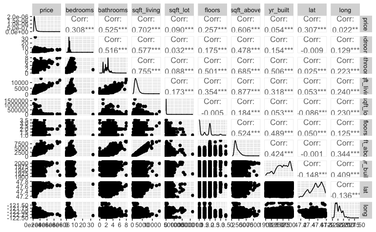

```r
ggpairs(house_data_numeric)
```

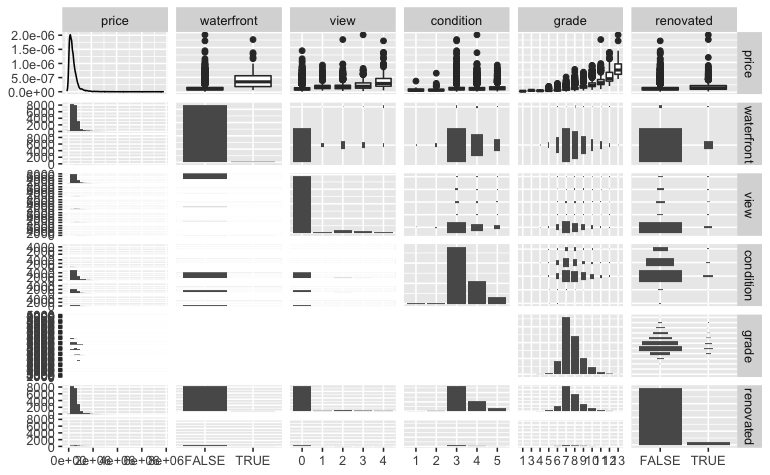

```r
ggpairs(house_data_nonnumeric)
```

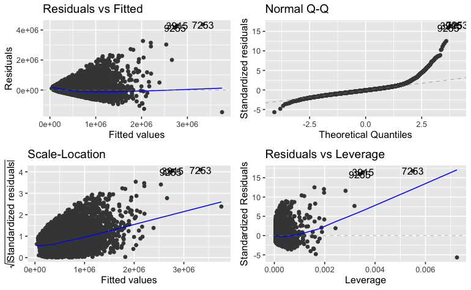

```r
mod1a <- lm(price ~ sqft_living, data = house_data)

autoplot(mod1a)
```

```r
summary(mod1a)
```

```
Call:
lm(formula = price ~ sqft_living, data = house_data)

Residuals:
     Min       1Q   Median       3Q      Max
-1476062  -147486   -24043   106182  4362067

Coefficients:
              Estimate Std. Error t value Pr(>|t|)
(Intercept) -43580.743   4402.690  -9.899   <2e-16 ***
sqft_living    280.624      1.936 144.920   <2e-16 ***
---
Signif. codes:  0 ‘***’ 0.001 ‘**’ 0.01 ‘*’ 0.05 ‘.’ 0.1 ‘ ’ 1

Residual standard error: 261500 on 21611 degrees of freedom
Multiple R-squared:  0.4929,    Adjusted R-squared:  0.4928
F-statistic: 2.1e+04 on 1 and 21611 DF,  p-value: < 2.2e-16
```

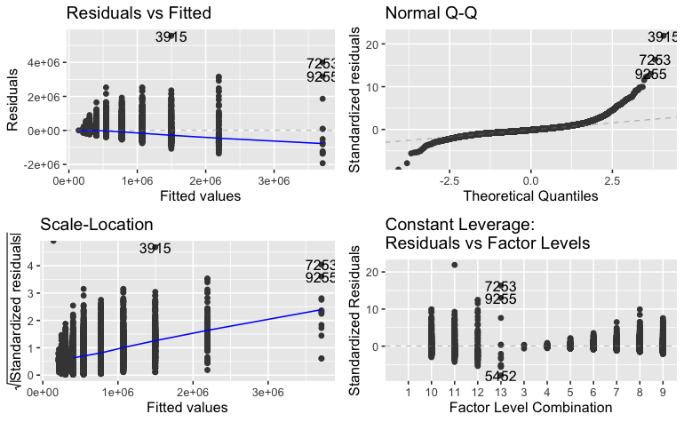

```r
mod1b <- lm(price ~  grade  , data = house_data)

autoplot(mod1b)
```

```r
summary(mod1b)
```

```
Call:
lm(formula = price ~ grade, data = house_data)

Residuals:
     Min       1Q   Median       3Q      Max
-1929615  -135853   -35090    89080  5565658

Coefficients:
            Estimate Std. Error t value Pr(>|t|)
(Intercept)   142000     254499   0.558 0.576878
grade3         63667     293870   0.217 0.828484
grade4         72381     258849   0.280 0.779767
grade5        106524     255024   0.418 0.676169
grade6        159920     254561   0.628 0.529868
grade7        260590     254513   1.024 0.305904
grade8        400853     254520   1.575 0.115285
grade9        631513     254547   2.481 0.013112 *
grade10       929771     254611   3.652 0.000261 ***
grade11      1354842     254817   5.317 1.07e-07 ***
grade12      2049222     255909   8.008 1.23e-15 ***
grade13      3567615     264106  13.508  < 2e-16 ***
---
Signif. codes:  0 ‘***’ 0.001 ‘**’ 0.01 ‘*’ 0.05 ‘.’ 0.1 ‘ ’ 1

Residual standard error: 254500 on 21601 degrees of freedom
Multiple R-squared:  0.5197,    Adjusted R-squared:  0.5195
F-statistic:  2125 on 11 and 21601 DF,  p-value: < 2.2e-16
```

mod1b is probably the best here

```r
residual_house_data <- house_data %>%
  add_residuals(mod1b) %>%
  select(- c(price, grade))

res_data_numeric <- residual_house_data %>%
  select(is.numeric)

res_data_nonnumeric <- residual_house_data %>%
  select( resid, !is.numeric)
```

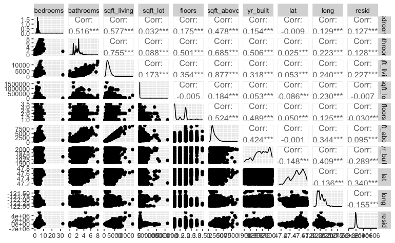

```r
ggpairs(res_data_numeric)
```

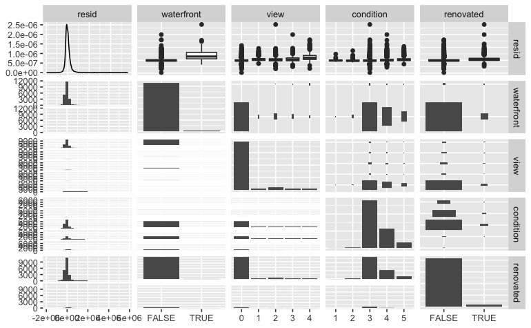

```r
ggpairs(res_data_nonnumeric)
```

## Model 2

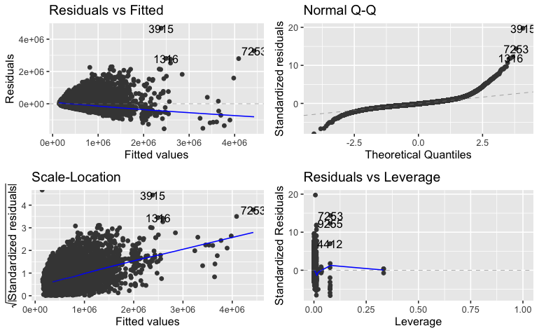

```r
mod2a <-  lm(price ~ grade + sqft_living, data = house_data)

autoplot(mod2a)
```

```r
summary(mod2a)
```

```
Call:
lm(formula = price ~ grade + sqft_living, data = house_data)

Residuals:
     Min       1Q   Median       3Q      Max
-1550528  -129352   -27914    92324  4677732

Coefficients:
              Estimate Std. Error t value Pr(>|t|)
(Intercept)  9.638e+04  2.375e+05   0.406   0.6849
grade3       1.543e+04  2.743e+05   0.056   0.9551
grade4       1.410e+04  2.416e+05   0.058   0.9535
grade5      -2.541e+03  2.380e+05  -0.011   0.9915
grade6       1.810e+04  2.376e+05   0.076   0.9393
grade7       4.046e+04  2.376e+05   0.170   0.8648
grade8       1.028e+05  2.376e+05   0.433   0.6653
grade9       2.260e+05  2.377e+05   0.951   0.3418
grade10      4.216e+05  2.378e+05   1.773   0.0762 .
grade11      7.090e+05  2.381e+05   2.978   0.0029 **
grade12      1.234e+06  2.393e+05   5.158 2.52e-07 ***
grade13      2.436e+06  2.473e+05   9.851  < 2e-16 ***
sqft_living  1.573e+02  2.781e+00  56.567  < 2e-16 ***
---
Signif. codes:  0 ‘***’ 0.001 ‘**’ 0.01 ‘*’ 0.05 ‘.’ 0.1 ‘ ’ 1

Residual standard error: 237500 on 21600 degrees of freedom
Multiple R-squared:  0.5817,    Adjusted R-squared:  0.5814
F-statistic:  2503 on 12 and 21600 DF,  p-value: < 2.2e-16
```

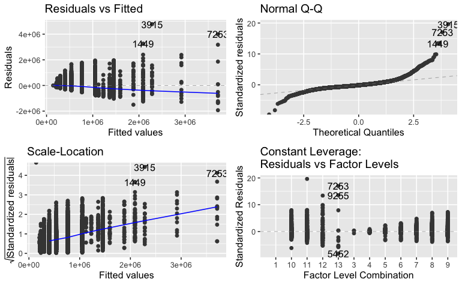

```r
mod2b <- lm(price ~ grade + waterfront, data = house_data)

autoplot(mod2b)
```

```r
summary(mod2b)
```

```
Call:
lm(formula = price ~ grade + waterfront, data = house_data)

Residuals:
     Min       1Q   Median       3Q      Max
-1929615  -132969   -32393    91481  4778940

Coefficients:
               Estimate Std. Error t value Pr(>|t|)
(Intercept)      142000     244366   0.581   0.5612
grade3            63667     282169   0.226   0.8215
grade4            72381     248543   0.291   0.7709
grade5            92834     244870   0.379   0.7046
grade6           155043     244426   0.634   0.5259
grade7           258469     244379   1.058   0.2902
grade8           395393     244386   1.618   0.1057
grade9           623595     244413   2.551   0.0107 *
grade10          909321     244474   3.719   0.0002 ***
grade11         1313326     244674   5.368 8.06e-08 ***
grade12         1947993     245731   7.927 2.35e-15 ***
grade13         3567615     253590  14.068  < 2e-16 ***
waterfrontTRUE   828234      19363  42.773  < 2e-16 ***
---
Signif. codes:  0 ‘***’ 0.001 ‘**’ 0.01 ‘*’ 0.05 ‘.’ 0.1 ‘ ’ 1

Residual standard error: 244400 on 21600 degrees of freedom
Multiple R-squared:  0.5572,    Adjusted R-squared:  0.557
F-statistic:  2265 on 12 and 21600 DF,  p-value: < 2.2e-16
```

mod2a is the better option here

```r
residual_house_data <- house_data %>%
  add_residuals(mod2a) %>%
  select(- c(price, grade, sqft_living))

res_data_numeric <- residual_house_data %>%
  select(is.numeric)

res_data_nonnumeric <- residual_house_data %>%
  select( resid, !is.numeric)
```

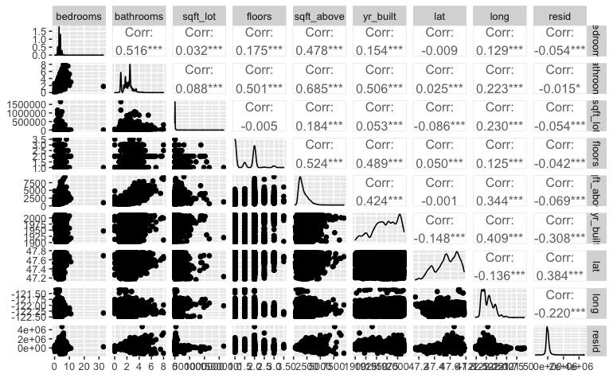

```r
ggpairs(res_data_numeric)
```

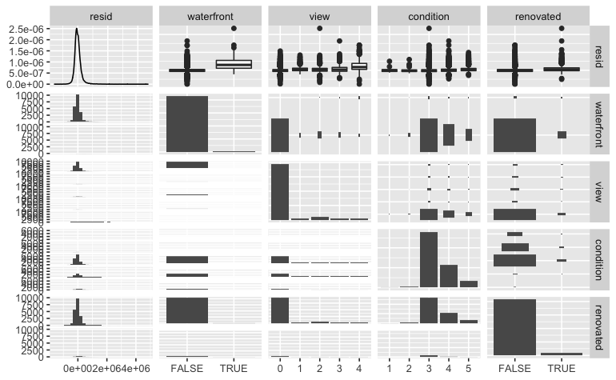

```r
ggpairs(res_data_nonnumeric)
```

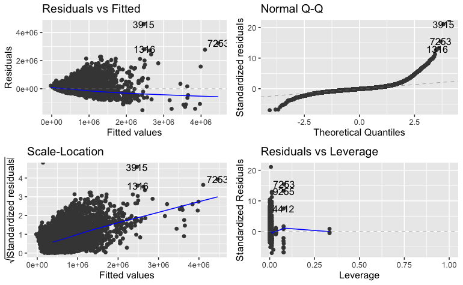

```r
mod3a <- lm(price ~ grade + sqft_living + lat, data = house_data)
autoplot(mod3a)
```

```r
summary(mod3a)
```

```
Call:
lm(formula = price ~ grade + sqft_living + lat, data = house_data)

Residuals:
     Min       1Q   Median       3Q      Max
-1528796  -105592   -19877    65573  4599064

Coefficients:
              Estimate Std. Error t value Pr(>|t|)
(Intercept) -3.167e+07  5.600e+05 -56.560  < 2e-16 ***
grade3       1.442e+05  2.529e+05   0.570  0.56873
grade4       3.540e+04  2.228e+05   0.159  0.87373
grade5       1.285e+04  2.195e+05   0.059  0.95332
grade6       9.338e+03  2.191e+05   0.043  0.96601
grade7       1.415e+04  2.191e+05   0.065  0.94851
grade8       6.418e+04  2.191e+05   0.293  0.76958
grade9       1.752e+05  2.192e+05   0.800  0.42399
grade10      3.556e+05  2.193e+05   1.622  0.10486
grade11      6.300e+05  2.196e+05   2.869  0.00412 **
grade12      1.148e+06  2.207e+05   5.204 1.97e-07 ***
grade13      2.309e+06  2.281e+05  10.126  < 2e-16 ***
sqft_living  1.653e+02  2.568e+00  64.377  < 2e-16 ***
lat          6.684e+05  1.084e+04  61.643  < 2e-16 ***
---
Signif. codes:  0 ‘***’ 0.001 ‘**’ 0.01 ‘*’ 0.05 ‘.’ 0.1 ‘ ’ 1

Residual standard error: 219000 on 21599 degrees of freedom
Multiple R-squared:  0.6443,    Adjusted R-squared:  0.644
F-statistic:  3009 on 13 and 21599 DF,  p-value: < 2.2e-16
```

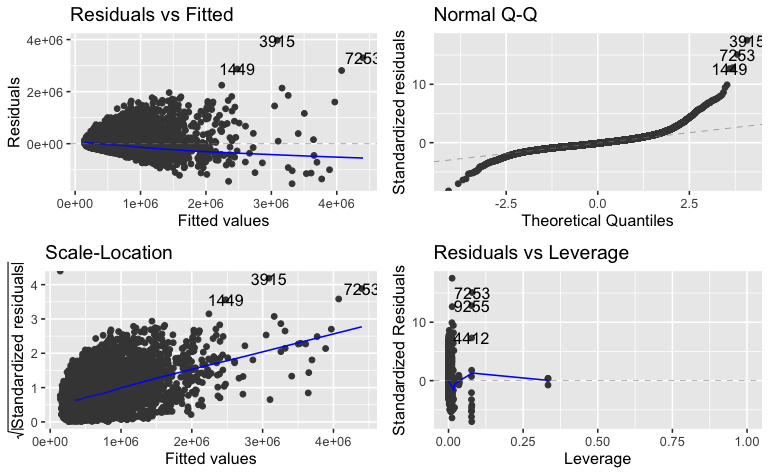

```r
mod3b <- lm(price ~ grade + sqft_living + waterfront, data = house_data)
autoplot(mod3b)
```

```r
summary(mod3b)
```

```
Call:
lm(formula = price ~ grade + sqft_living + waterfront, data = house_data)

Residuals:
     Min       1Q   Median       3Q      Max
-1536738  -126147   -25804    93564  3972950

Coefficients:
                 Estimate Std. Error t value Pr(>|t|)
(Intercept)     9.806e+04  2.280e+05   0.430   0.6671
grade3          1.720e+04  2.633e+05   0.065   0.9479
grade4          1.625e+04  2.319e+05   0.070   0.9441
grade5         -1.136e+04  2.285e+05  -0.050   0.9604
grade6          1.875e+04  2.281e+05   0.082   0.9345
grade7          4.658e+04  2.280e+05   0.204   0.8382
grade8          1.087e+05  2.281e+05   0.476   0.6338
grade9          2.335e+05  2.281e+05   1.023   0.3062
grade10         4.212e+05  2.283e+05   1.845   0.0650 .
grade11         6.939e+05  2.285e+05   3.036   0.0024 **
grade12         1.169e+06  2.297e+05   5.091  3.6e-07 ***
grade13         2.478e+06  2.374e+05  10.438  < 2e-16 ***
sqft_living     1.515e+02  2.673e+00  56.684  < 2e-16 ***
waterfrontTRUE  7.764e+05  1.809e+04  42.920  < 2e-16 ***
---
Signif. codes:  0 ‘***’ 0.001 ‘**’ 0.01 ‘*’ 0.05 ‘.’ 0.1 ‘ ’ 1

Residual standard error: 228000 on 21599 degrees of freedom
Multiple R-squared:  0.6145,    Adjusted R-squared:  0.6143
F-statistic:  2649 on 13 and 21599 DF,  p-value: < 2.2e-16
```

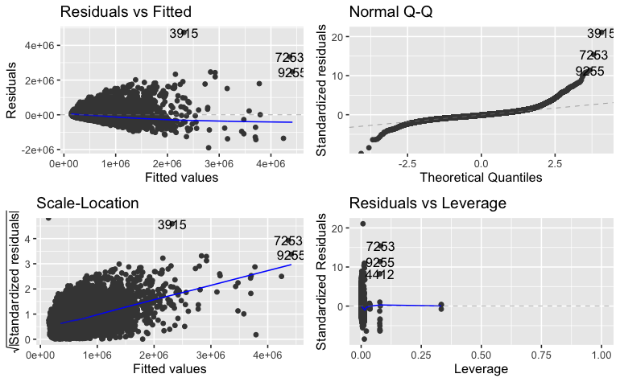

```r
mod3c <- lm(price ~ grade + sqft_living + view, data = house_data)
autoplot(mod3c)
```

```r
summary(mod3c)
```

```
Call:
lm(formula = price ~ grade + sqft_living + view, data = house_data)

Residuals:
     Min       1Q   Median       3Q      Max
-1895788  -123282   -23838    92320  4745060

Coefficients:
              Estimate Std. Error t value Pr(>|t|)
(Intercept)  1.008e+05  2.261e+05   0.446  0.65593
grade3       2.005e+04  2.611e+05   0.077  0.93880
grade4       3.894e+03  2.300e+05   0.017  0.98649
grade5      -5.996e+03  2.266e+05  -0.026  0.97889
grade6       2.368e+04  2.262e+05   0.105  0.91664
grade7       5.353e+04  2.262e+05   0.237  0.81290
grade8       1.112e+05  2.262e+05   0.492  0.62290
grade9       2.284e+05  2.263e+05   1.009  0.31288
grade10      4.117e+05  2.264e+05   1.818  0.06902 .
grade11      6.784e+05  2.267e+05   2.993  0.00277 **
grade12      1.139e+06  2.278e+05   5.001 5.75e-07 ***
grade13      2.365e+06  2.354e+05  10.047  < 2e-16 ***
sqft_living  1.422e+02  2.672e+00  53.241  < 2e-16 ***
view1        1.738e+05  1.256e+04  13.839  < 2e-16 ***
view2        1.102e+05  7.563e+03  14.577  < 2e-16 ***
view3        1.837e+05  1.032e+04  17.807  < 2e-16 ***
view4        5.431e+05  1.307e+04  41.564  < 2e-16 ***
---
Signif. codes:  0 ‘***’ 0.001 ‘**’ 0.01 ‘*’ 0.05 ‘.’ 0.1 ‘ ’ 1

Residual standard error: 226100 on 21596 degrees of freedom
Multiple R-squared:  0.6209,    Adjusted R-squared:  0.6206
F-statistic:  2211 on 16 and 21596 DF,  p-value: < 2.2e-16
```

mod3a

```r
residual_house_data <- house_data %>%
  add_residuals(mod3a) %>%
  select(- c(price, grade, sqft_living, lat))

res_data_numeric <- residual_house_data %>%
  select(is.numeric)

res_data_nonnumeric <- residual_house_data %>%
  select( resid, !is.numeric)
```

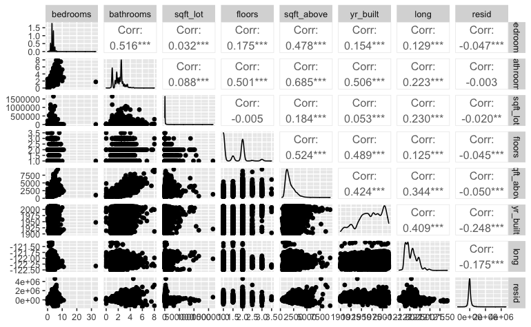

```r
ggpairs(res_data_numeric)
```

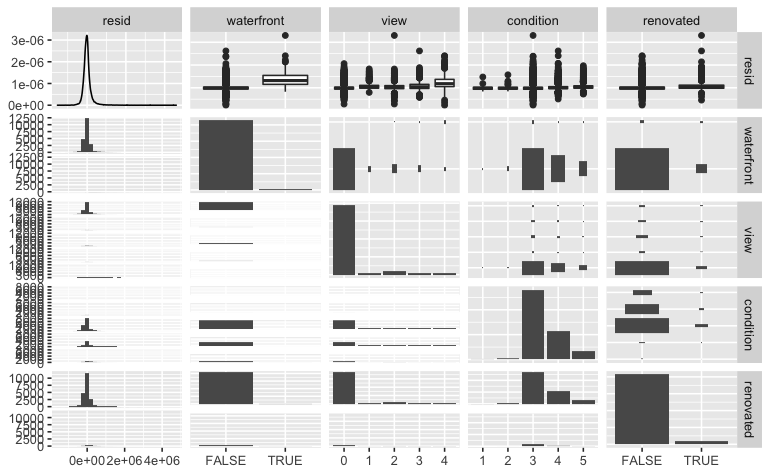

```r
ggpairs(res_data_nonnumeric)
```

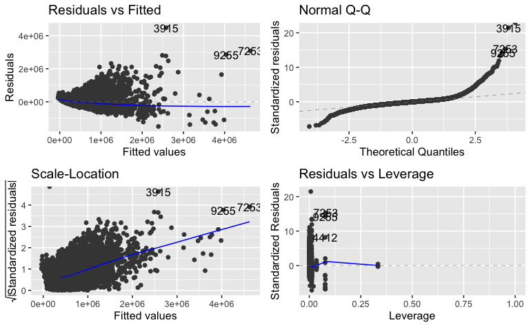

```r
mod4a <- lm(price ~ grade + sqft_living + lat + yr_built, data = house_data)

autoplot(mod4a)
```

```r
summary(mod4a)
```

```
Call:
lm(formula = price ~ grade + sqft_living + lat + yr_built, data = house_data)

Residuals:
     Min       1Q   Median       3Q      Max
-1493935   -99411   -13537    72530  4481513

Coefficients:
              Estimate Std. Error t value Pr(>|t|)
(Intercept) -2.132e+07  5.829e+05 -36.568  < 2e-16 ***
grade3       7.742e+04  2.419e+05   0.320 0.748918
grade4      -2.924e+04  2.130e+05  -0.137 0.890852
grade5      -6.008e+04  2.099e+05  -0.286 0.774709
grade6      -4.141e+04  2.095e+05  -0.198 0.843332
grade7       2.096e+04  2.095e+05   0.100 0.920318
grade8       1.164e+05  2.095e+05   0.556 0.578484
grade9       2.505e+05  2.096e+05   1.195 0.232081
grade10      4.368e+05  2.097e+05   2.083 0.037287 *
grade11      7.204e+05  2.100e+05   3.431 0.000602 ***
grade12      1.241e+06  2.110e+05   5.881 4.14e-09 ***
grade13      2.370e+06  2.181e+05  10.865  < 2e-16 ***
sqft_living  1.634e+02  2.456e+00  66.534  < 2e-16 ***
lat          5.566e+05  1.066e+04  52.198  < 2e-16 ***
yr_built    -2.568e+03  5.712e+01 -44.968  < 2e-16 ***
---
Signif. codes:  0 ‘***’ 0.001 ‘**’ 0.01 ‘*’ 0.05 ‘.’ 0.1 ‘ ’ 1

Residual standard error: 209500 on 21598 degrees of freedom
Multiple R-squared:  0.6747,    Adjusted R-squared:  0.6745
F-statistic:  3200 on 14 and 21598 DF,  p-value: < 2.2e-16
```

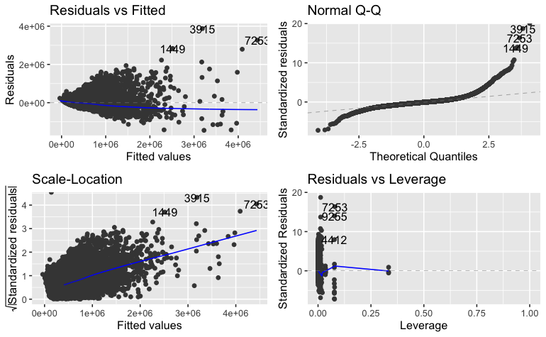

```r
mod4b <- lm(price ~ grade + sqft_living + lat + waterfront, data = house_data)

autoplot(mod4b)
```

```r
summary(mod4b)
```

```
Call:
lm(formula = price ~ grade + sqft_living + lat + waterfront,
    data = house_data)

Residuals:
     Min       1Q   Median       3Q      Max
-1445584  -102052   -16859    67035  3873654

Coefficients:
                 Estimate Std. Error t value Pr(>|t|)
(Intercept)    -3.214e+07  5.321e+05 -60.402  < 2e-16 ***
grade3          1.479e+05  2.403e+05   0.615  0.53830
grade4          3.792e+04  2.116e+05   0.179  0.85779
grade5          4.016e+03  2.085e+05   0.019  0.98463
grade6          9.882e+03  2.081e+05   0.047  0.96214
grade7          2.005e+04  2.081e+05   0.096  0.92324
grade8          6.964e+04  2.082e+05   0.335  0.73794
grade9          1.822e+05  2.082e+05   0.875  0.38150
grade10         3.542e+05  2.083e+05   1.700  0.08909 .
grade11         6.133e+05  2.086e+05   2.940  0.00328 **
grade12         1.080e+06  2.096e+05   5.153 2.58e-07 ***
grade13         2.350e+06  2.167e+05  10.848  < 2e-16 ***
sqft_living     1.595e+02  2.442e+00  65.291  < 2e-16 ***
lat             6.782e+05  1.030e+04  65.829  < 2e-16 ***
waterfrontTRUE  7.979e+05  1.651e+04  48.318  < 2e-16 ***
---
Signif. codes:  0 ‘***’ 0.001 ‘**’ 0.01 ‘*’ 0.05 ‘.’ 0.1 ‘ ’ 1

Residual standard error: 208100 on 21598 degrees of freedom
Multiple R-squared:  0.679, Adjusted R-squared:  0.6787
F-statistic:  3263 on 14 and 21598 DF,  p-value: < 2.2e-16
```

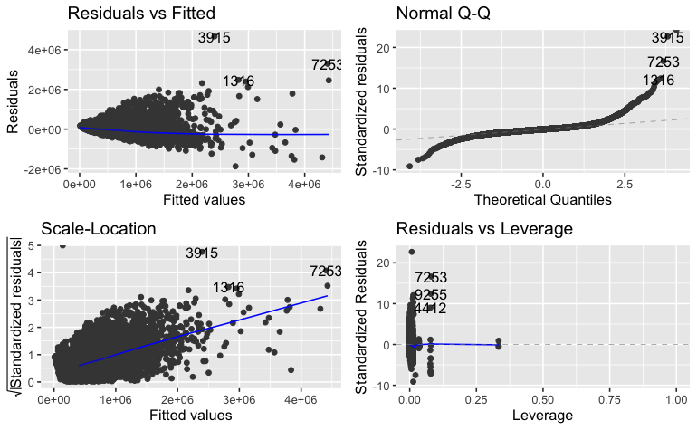

```r
mod4c <- lm(price ~ grade + sqft_living + lat + view, data = house_data)

autoplot(mod4c)
```

```r
summary(mod4c)
```

```
Call:
lm(formula = price ~ grade + sqft_living + lat + view, data = house_data)

Residuals:
     Min       1Q   Median       3Q      Max
-1870696   -97967   -14610    65386  4666294

Coefficients:
              Estimate Std. Error t value Pr(>|t|)
(Intercept) -3.181e+07  5.281e+05 -60.235  < 2e-16 ***
grade3       1.494e+05  2.384e+05   0.627  0.53089
grade4       2.602e+04  2.100e+05   0.124  0.90138
grade5       9.598e+03  2.069e+05   0.046  0.96300
grade6       1.501e+04  2.065e+05   0.073  0.94207
grade7       2.735e+04  2.065e+05   0.132  0.89465
grade8       7.258e+04  2.065e+05   0.351  0.72529
grade9       1.773e+05  2.066e+05   0.858  0.39072
grade10      3.451e+05  2.067e+05   1.669  0.09508 .
grade11      5.984e+05  2.070e+05   2.891  0.00384 **
grade12      1.053e+06  2.080e+05   5.060 4.22e-07 ***
grade13      2.237e+06  2.150e+05  10.406  < 2e-16 ***
sqft_living  1.500e+02  2.442e+00  61.437  < 2e-16 ***
lat          6.713e+05  1.023e+04  65.652  < 2e-16 ***
view1        1.632e+05  1.147e+04  14.223  < 2e-16 ***
view2        1.129e+05  6.905e+03  16.349  < 2e-16 ***
view3        1.996e+05  9.423e+03  21.183  < 2e-16 ***
view4        5.418e+05  1.193e+04  45.414  < 2e-16 ***
---
Signif. codes:  0 ‘***’ 0.001 ‘**’ 0.01 ‘*’ 0.05 ‘.’ 0.1 ‘ ’ 1

Residual standard error: 206500 on 21595 degrees of freedom
Multiple R-squared:  0.684, Adjusted R-squared:  0.6837
F-statistic:  2749 on 17 and 21595 DF,  p-value: < 2.2e-16
```

```r
anova(mod3a, mod4c)
```

```
Analysis of Variance Table

Model 1: price ~ grade + sqft_living + lat
Model 2: price ~ grade + sqft_living + lat + view
  Res.Df        RSS Df  Sum of Sq      F    Pr(>F)
1  21599 1.0363e+15
2  21595 9.2058e+14  4 1.1568e+14 678.43 < 2.2e-16 ***
---
Signif. codes:  0 ‘***’ 0.001 ‘**’ 0.01 ‘*’ 0.05 ‘.’ 0.1 ‘ ’ 1
```

mod4c

## Extension

grade:sqft_living

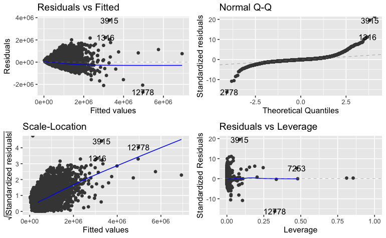

```r
mod5a <- lm(price ~ grade + sqft_living + lat + view + grade:sqft_living, data = house_data)

autoplot(mod5a)
```

```r
summary(mod5a)
```

```
Call:
lm(formula = price ~ grade + sqft_living + lat + view + grade:sqft_living,
    data = house_data)

Residuals:
     Min       1Q   Median       3Q      Max
-2690620   -95188   -15668    60992  3776079

Coefficients: (1 not defined because of singularities)
                      Estimate Std. Error t value Pr(>|t|)
(Intercept)         -3.172e+07  5.158e+05 -61.494  < 2e-16 ***
grade3               1.303e+06  1.156e+06   1.127   0.2597
grade4               2.541e+05  2.326e+05   1.093   0.2746
grade5               2.244e+05  2.052e+05   1.093   0.2742
grade6               2.505e+05  2.022e+05   1.239   0.2153
grade7               2.769e+05  2.018e+05   1.372   0.1700
grade8               2.756e+05  2.019e+05   1.365   0.1723
grade9               3.166e+05  2.024e+05   1.564   0.1179
grade10              1.888e+05  2.037e+05   0.927   0.3539
grade11              6.976e+04  2.069e+05   0.337   0.7360
grade12              4.274e+05  2.168e+05   1.972   0.0486 *
grade13             -1.742e+06  2.890e+05  -6.028 1.69e-09 ***
sqft_living          7.040e+02  2.775e+01  25.372  < 2e-16 ***
lat                  6.660e+05  9.989e+03  66.678  < 2e-16 ***
view1                1.649e+05  1.120e+04  14.720  < 2e-16 ***
view2                1.133e+05  6.749e+03  16.792  < 2e-16 ***
view3                1.929e+05  9.206e+03  20.959  < 2e-16 ***
view4                5.268e+05  1.167e+04  45.140  < 2e-16 ***
grade3:sqft_living  -2.221e+03  1.899e+03  -1.170   0.2422
grade4:sqft_living  -6.565e+02  1.683e+02  -3.901 9.62e-05 ***
grade5:sqft_living  -6.089e+02  4.552e+01 -13.375  < 2e-16 ***
grade6:sqft_living  -6.166e+02  2.994e+01 -20.595  < 2e-16 ***
grade7:sqft_living  -6.065e+02  2.805e+01 -21.617  < 2e-16 ***
grade8:sqft_living  -5.731e+02  2.808e+01 -20.409  < 2e-16 ***
grade9:sqft_living  -5.461e+02  2.837e+01 -19.252  < 2e-16 ***
grade10:sqft_living -4.634e+02  2.884e+01 -16.068  < 2e-16 ***
grade11:sqft_living -3.966e+02  2.957e+01 -13.409  < 2e-16 ***
grade12:sqft_living -4.094e+02  3.107e+01 -13.179  < 2e-16 ***
grade13:sqft_living         NA         NA      NA       NA
---
Signif. codes:  0 ‘***’ 0.001 ‘**’ 0.01 ‘*’ 0.05 ‘.’ 0.1 ‘ ’ 1

Residual standard error: 201500 on 21585 degrees of freedom
Multiple R-squared:  0.6991,    Adjusted R-squared:  0.6987
F-statistic:  1857 on 27 and 21585 DF,  p-value: < 2.2e-16
```

grade:lat

```r
mod5b <- lm(price ~ grade + sqft_living + lat + view + grade:lat, data = house_data)



summary(mod5b)
```

```
Call:
lm(formula = price ~ grade + sqft_living + lat + view + grade:lat,
    data = house_data)

Residuals:
     Min       1Q   Median       3Q      Max
-1772020   -93448   -16749    62402  4625982

Coefficients: (1 not defined because of singularities)
              Estimate Std. Error t value Pr(>|t|)
(Intercept)  2.632e+07  4.153e+07   0.634 0.526215
grade3      -3.887e+07  5.741e+07  -0.677 0.498382
grade4      -3.792e+07  4.503e+07  -0.842 0.399698
grade5      -4.353e+07  4.184e+07  -1.040 0.298152
grade6      -4.829e+07  4.156e+07  -1.162 0.245259
grade7      -5.378e+07  4.153e+07  -1.295 0.195341
grade8      -5.978e+07  4.154e+07  -1.439 0.150133
grade9      -7.201e+07  4.155e+07  -1.733 0.083108 .
grade10     -8.674e+07  4.162e+07  -2.084 0.037163 *
grade11     -9.347e+07  4.192e+07  -2.230 0.025770 *
grade12     -1.454e+08  4.346e+07  -3.346 0.000822 ***
grade13      2.361e+06  2.314e+05  10.203  < 2e-16 ***
sqft_living  1.503e+02  2.425e+00  61.966  < 2e-16 ***
lat         -5.517e+05  8.737e+05  -0.631 0.527758
view1        1.625e+05  1.138e+04  14.279  < 2e-16 ***
view2        1.145e+05  6.853e+03  16.701  < 2e-16 ***
view3        2.040e+05  9.355e+03  21.804  < 2e-16 ***
view4        5.398e+05  1.185e+04  45.572  < 2e-16 ***
grade3:lat   8.192e+05  1.210e+06   0.677 0.498454
grade4:lat   7.980e+05  9.474e+05   0.842 0.399616
grade5:lat   9.158e+05  8.802e+05   1.040 0.298153
grade6:lat   1.016e+06  8.743e+05   1.162 0.245104
grade7:lat   1.132e+06  8.738e+05   1.296 0.195094
grade8:lat   1.259e+06  8.739e+05   1.441 0.149645
grade9:lat   1.519e+06  8.742e+05   1.737 0.082408 .
grade10:lat  1.831e+06  8.757e+05   2.092 0.036493 *
grade11:lat  1.978e+06  8.818e+05   2.243 0.024912 *
grade12:lat  3.079e+06  9.142e+05   3.368 0.000759 ***
grade13:lat         NA         NA      NA       NA
---
Signif. codes:  0 ‘***’ 0.001 ‘**’ 0.01 ‘*’ 0.05 ‘.’ 0.1 ‘ ’ 1

Residual standard error: 204800 on 21585 degrees of freedom
Multiple R-squared:  0.6892,    Adjusted R-squared:  0.6889
F-statistic:  1773 on 27 and 21585 DF,  p-value: < 2.2e-16
```

grade:waterfront

```r
mod5c <- lm(price ~ grade + sqft_living + lat + view + grade:waterfront, data = house_data)



summary(mod5c)
```

```
Call:
lm(formula = price ~ grade + sqft_living + lat + view + grade:waterfront,
    data = house_data)

Residuals:
     Min       1Q   Median       3Q      Max
-1573323   -97870   -14814    64556  3569273

Coefficients: (4 not defined because of singularities)
                         Estimate Std. Error t value Pr(>|t|)
(Intercept)            -3.194e+07  5.128e+05 -62.280  < 2e-16 ***
grade3                  1.503e+05  2.314e+05   0.649 0.516175
grade4                  2.643e+04  2.038e+05   0.130 0.896824
grade5                  1.564e+04  2.008e+05   0.078 0.937913
grade6                  1.681e+04  2.005e+05   0.084 0.933161
grade7                  2.928e+04  2.005e+05   0.146 0.883876
grade8                  7.524e+04  2.005e+05   0.375 0.707447
grade9                  1.827e+05  2.005e+05   0.911 0.362223
grade10                 3.388e+05  2.006e+05   1.689 0.091311 .
grade11                 5.674e+05  2.009e+05   2.824 0.004745 **
grade12                 9.966e+05  2.020e+05   4.932 8.18e-07 ***
grade13                 2.300e+06  2.087e+05  11.023  < 2e-16 ***
sqft_living             1.490e+02  2.373e+00  62.806  < 2e-16 ***
lat                     6.740e+05  9.930e+03  67.875  < 2e-16 ***
view1                   1.649e+05  1.114e+04  14.803  < 2e-16 ***
view2                   1.114e+05  6.708e+03  16.613  < 2e-16 ***
view3                   1.876e+05  9.190e+03  20.416  < 2e-16 ***
view4                   3.074e+05  1.427e+04  21.538  < 2e-16 ***
grade1:waterfrontTRUE          NA         NA      NA       NA
grade3:waterfrontTRUE          NA         NA      NA       NA
grade4:waterfrontTRUE          NA         NA      NA       NA
grade5:waterfrontTRUE  -7.894e+04  1.017e+05  -0.777 0.437423
grade6:waterfrontTRUE   1.004e+05  5.886e+04   1.705 0.088234 .
grade7:waterfrontTRUE   1.450e+05  4.350e+04   3.334 0.000857 ***
grade8:waterfrontTRUE   3.609e+05  3.415e+04  10.569  < 2e-16 ***
grade9:waterfrontTRUE   4.528e+05  4.157e+04  10.892  < 2e-16 ***
grade10:waterfrontTRUE  9.640e+05  3.995e+04  24.131  < 2e-16 ***
grade11:waterfrontTRUE  1.139e+06  4.756e+04  23.950  < 2e-16 ***
grade12:waterfrontTRUE  9.813e+05  6.565e+04  14.949  < 2e-16 ***
grade13:waterfrontTRUE         NA         NA      NA       NA
---
Signif. codes:  0 ‘***’ 0.001 ‘**’ 0.01 ‘*’ 0.05 ‘.’ 0.1 ‘ ’ 1

Residual standard error: 200400 on 21587 degrees of freedom
Multiple R-squared:  0.7023,    Adjusted R-squared:  0.702
F-statistic:  2037 on 25 and 21587 DF,  p-value: < 2.2e-16
```

sqftliving:lat

```r
mod5d <- lm(price ~ grade + sqft_living + lat + view + sqft_living:lat, data = house_data)



summary(mod5d)
```

```
Call:
lm(formula = price ~ grade + sqft_living + lat + view + sqft_living:lat,
    data = house_data)

Residuals:
     Min       1Q   Median       3Q      Max
-1801550   -90421   -16895    62192  4513316

Coefficients:
                  Estimate Std. Error t value Pr(>|t|)
(Intercept)     -5312750.2  1337558.9  -3.972 7.15e-05 ***
grade3             76277.1   235932.4   0.323  0.74647
grade4             19369.5   207790.5   0.093  0.92573
grade5             11833.3   204722.8   0.058  0.95391
grade6             27932.1   204356.7   0.137  0.89128
grade7             48240.2   204335.9   0.236  0.81337
grade8             97556.8   204365.6   0.477  0.63311
grade9            199380.9   204430.4   0.975  0.32942
grade10           362177.5   204534.5   1.771  0.07662 .
grade11           608250.2   204790.8   2.970  0.00298 **
grade12          1055341.4   205814.3   5.128 2.96e-07 ***
grade13          2162400.9   212748.0  10.164  < 2e-16 ***
sqft_living       -13156.7      618.4 -21.276  < 2e-16 ***
lat               113926.4    27807.0   4.097 4.20e-05 ***
view1             160892.9    11350.9  14.174  < 2e-16 ***
view2             114616.6     6833.1  16.774  < 2e-16 ***
view3             204897.9     9327.0  21.968  < 2e-16 ***
view4             535345.2    11807.6  45.339  < 2e-16 ***
sqft_living:lat      279.7       13.0  21.519  < 2e-16 ***
---
Signif. codes:  0 ‘***’ 0.001 ‘**’ 0.01 ‘*’ 0.05 ‘.’ 0.1 ‘ ’ 1

Residual standard error: 204300 on 21594 degrees of freedom
Multiple R-squared:  0.6906,    Adjusted R-squared:  0.6903
F-statistic:  2678 on 18 and 21594 DF,  p-value: < 2.2e-16
```

sqftliving:waterfront

```r
mod5e <- lm(price ~ grade + sqft_living + lat + view + sqft_living:waterfront, data = house_data)



summary(mod5e)
```

```
Call:
lm(formula = price ~ grade + sqft_living + lat + view + sqft_living:waterfront,
    data = house_data)

Residuals:
     Min       1Q   Median       3Q      Max
-1486302   -97744   -14788    64532  3262598

Coefficients:
                             Estimate Std. Error t value Pr(>|t|)
(Intercept)                -3.197e+07  5.087e+05 -62.856  < 2e-16 ***
grade3                      1.519e+05  2.297e+05   0.661  0.50832
grade4                      2.834e+04  2.023e+05   0.140  0.88857
grade5                      1.579e+04  1.993e+05   0.079  0.93685
grade6                      2.070e+04  1.989e+05   0.104  0.91715
grade7                      3.553e+04  1.989e+05   0.179  0.85826
grade8                      8.373e+04  1.989e+05   0.421  0.67386
grade9                      1.955e+05  1.990e+05   0.982  0.32594
grade10                     3.624e+05  1.991e+05   1.820  0.06880 .
grade11                     5.952e+05  1.994e+05   2.986  0.00283 **
grade12                     9.983e+05  2.004e+05   4.982 6.33e-07 ***
grade13                     2.349e+06  2.071e+05  11.343  < 2e-16 ***
sqft_living                 1.441e+02  2.357e+00  61.158  < 2e-16 ***
lat                         6.748e+05  9.850e+03  68.511  < 2e-16 ***
view1                       1.645e+05  1.105e+04  14.892  < 2e-16 ***
view2                       1.099e+05  6.652e+03  16.523  < 2e-16 ***
view3                       1.844e+05  9.084e+03  20.302  < 2e-16 ***
view4                       2.519e+05  1.349e+04  18.672  < 2e-16 ***
sqft_living:waterfrontTRUE  2.165e+02  5.282e+00  40.989  < 2e-16 ***
---
Signif. codes:  0 ‘***’ 0.001 ‘**’ 0.01 ‘*’ 0.05 ‘.’ 0.1 ‘ ’ 1

Residual standard error: 198900 on 21594 degrees of freedom
Multiple R-squared:  0.7068,    Adjusted R-squared:  0.7065
F-statistic:  2892 on 18 and 21594 DF,  p-value: < 2.2e-16
```

lat:waterfront

```r
mod5f <- lm(price ~ grade + sqft_living + lat + view + lat:waterfront, data = house_data)



summary(mod5f)
```

[output not shown]

```r
anova(mod4a, mod5c)
```

```
Analysis of Variance Table

Model 1: price ~ grade + sqft_living + lat + yr_built
Model 2: price ~ grade + sqft_living + lat + view + grade:waterfront
  Res.Df        RSS Df  Sum of Sq      F    Pr(>F)
1  21598 9.4755e+14
2  21587 8.6704e+14 11 8.0504e+13 182.21 < 2.2e-16 ***
---
Signif. codes:  0 ‘***’ 0.001 ‘**’ 0.01 ‘*’ 0.05 ‘.’ 0.1 ‘ ’ 1
```

```r
anova(mod5c, mod4a)
```

```
Analysis of Variance Table

Model 1: price ~ grade + sqft_living + lat + view + grade:waterfront
Model 2: price ~ grade + sqft_living + lat + yr_built
  Res.Df        RSS  Df   Sum of Sq      F    Pr(>F)
1  21587 8.6704e+14
2  21598 9.4755e+14 -11 -8.0504e+13 182.21 < 2.2e-16 ***
---
Signif. codes:  0 ‘***’ 0.001 ‘**’ 0.01 ‘*’ 0.05 ‘.’ 0.1 ‘ ’ 1
```

```r
calc.relimp(mod4a, type = "lmg", rela = TRUE)
```

```
Response variable: price
Total response variance: 134782378397
Analysis based on 21613 observations

14 Regressors:
Some regressors combined in groups:
        Group  grade : grade3 grade4 grade5 grade6 grade7 grade8 grade9 grade10 grade11 grade12 grade13

 Relative importance of 4 (groups of) regressors assessed:
 grade sqft_living lat yr_built

Proportion of variance explained by model: 67.47%
Metrics are normalized to sum to 100% (rela=TRUE).

Relative importance metrics:

                   lmg
grade       0.45234793
sqft_living 0.41292696
lat         0.09809759
yr_built    0.03662753

Average coefficients for different model sizes:

                  1group      2groups      3groups      4groups
grade3        63666.6672   69680.5509   73701.3572   77416.5146
grade4        72381.0351   34514.9701      86.4573  -29235.6859
grade5       106523.9716   46648.4183   -9624.3207  -60079.1942
grade6       159919.6380   89701.2340   21910.3579  -41409.2380
grade7       260590.2629  183125.4894  102723.8679   20956.8440
grade8       400852.7662  313128.1313  217874.3072  116416.1783
grade9       631513.1864  514630.5870  387044.8629  250482.0434
grade10      929771.0746  776778.8055  611642.6363  436768.8912
grade11     1354841.7274 1156878.2824  944314.7067  720448.1332
grade12     2049222.0006 1795614.3859 1524679.6350 1240983.8377
grade13     3567615.3852 3183496.6514 2781641.5453 2369661.2778
sqft_living     280.6236     245.6026     205.1658     163.3972
lat          813411.5832  734705.1674  614095.2077  556557.5636
yr_built        675.0698   -1454.6530   -2561.6237   -2568.4167
```